# Computing Statistics_Project Report

CHO seo hyeon

2023-06-23

# 문제1: Data Preprocessing

### 문제1-1.

```r
pm10 <- data.frame(NULL)

for (year in 2009:2022) {
  file_path <- paste0("C:/Users/Samsung/Desktop/PM10/",year,".csv")
  data <- read.csv(file_path, fileEncoding='euc-kr')
  data <- data[,3:4]
  pm10 <- rbind(pm10, data)
}

head(pm10)
```

```
##               일시 X1시간평균.미세먼지농도.....
## 1 2009-01-01 00:00                           38
## 2 2009-01-01 01:00                           50
## 3 2009-01-01 02:00                           46
## 4 2009-01-01 03:00                           44
## 5 2009-01-01 04:00                           43
## 6 2009-01-01 05:00                           43
```

- 시간별 pm10 농도를 데이터 프레임 pm10으로 병합하였다

### 문제1-2.

```r
library(tidyverse)
pm10 <- data.frame(NULL)
for (year in 2009:2022) {
  file_path <- paste0("C:/Users/Samsung/Desktop/PM10/",year,".csv")
  data <- read.csv(file_path, fileEncoding='euc-kr')
  data <- data[,3:4]
  pm10 <- rbind(pm10, data)
}

df <- pm10 %>%
  separate(일시, c("Year", "Month", "Time"), "-") %>%
  separate(Time,c("Date","Time")," ") %>%
  filter(Month %in% c('03','04','05')) %>%
  unite(일시,Year,Month,Date,sep="-")

daily_max_pm10 <- df %>%
  mutate(일시=as.Date(일시),
         X1시간평균.미세먼지농도.....=as.numeric(X1시간평균.미세먼지농도.....))%>%
  group_by(일시) %>%
  summarise(max_pm10=max(X1시간평균.미세먼지농도.....,na.rm=TRUE))
head(daily_max_pm10)
```

```
## # A tibble: 6 × 2
##   일시       max_pm10
##   <date>        <dbl>
## 1 2009-03-01       84
## 2 2009-03-02       60
## 3 2009-03-03       59
## 4 2009-03-04      126
## 5 2009-03-05      130
## 6 2009-03-06      170
```

- 시간별 pm10 농도를 데이터 프레임 pm10으로 병합한 후, 각 년도별로 3, 4, 5월의 자료만 추출하여 데이터 프레임 df에 저장하였다.
- df로부터 일간 pm10 최대 농도 자료 벡터를 추출하여 daily_max_pm10에 저장하였다.

# 문제2: Exploratory Data Analysis

```r
library(tidyverse)
pm10 <- data.frame()
for (year in 2009:2022) {
  file_path <- paste0("C:/Users/Samsung/Desktop/PM10/",year,".csv")
  data <- read.csv(file_path, fileEncoding='euc-kr')
  data <- data[,3:4]
  pm10 <- rbind(pm10, data)
}

df <- pm10 %>%
  separate(일시, c("Year", "Month", "Time"), "-") %>%
  separate(Time,c("Date","Time")," ") %>%
  filter(Month %in% c('03','04','05')) %>%
  unite(일시,Year,Month,Date,sep="-") %>%
  filter(!is.na(X1시간평균.미세먼지농도.....))

daily_max_pm10 <- df %>%
  mutate(일시=as.Date(일시),
         X1시간평균.미세먼지농도.....=as.numeric(X1시간평균.미세먼지농도.....)) %>%
  group_by(일시) %>%
  summarise(max_pm10=max(X1시간평균.미세먼지농도.....,na.rm=TRUE))
head(daily_max_pm10)
```

```
## # A tibble: 6 × 2
##   일시       max_pm10
##   <date>        <dbl>
## 1 2009-03-01       84
## 2 2009-03-02       60
## 3 2009-03-03       59
## 4 2009-03-04      126
## 5 2009-03-05      130
## 6 2009-03-06      170
```

```r
daily_max_pm10 %>% summary(daily_max_pm10)
```

```
##       일시               max_pm10
##  Min.   :2009-03-01   Min.   :  9.00
##  1st Qu.:2012-04-15   1st Qu.: 59.00
##  Median :2015-05-31   Median : 77.00
##  Mean   :2015-10-14   Mean   : 90.05
##  3rd Qu.:2019-04-15   3rd Qu.:100.00
##  Max.   :2022-05-31   Max.   :775.00
```

```r
daily_max_pm10 %>%
  summarise(mean_max=mean(max_pm10),
            var_max=var(max_pm10),
            sd_max=sd(max_pm10))
```

```
## # A tibble: 1 × 3
##   mean_max var_max sd_max
##      <dbl>   <dbl>  <dbl>
## 1     90.1   4153.   64.4
```

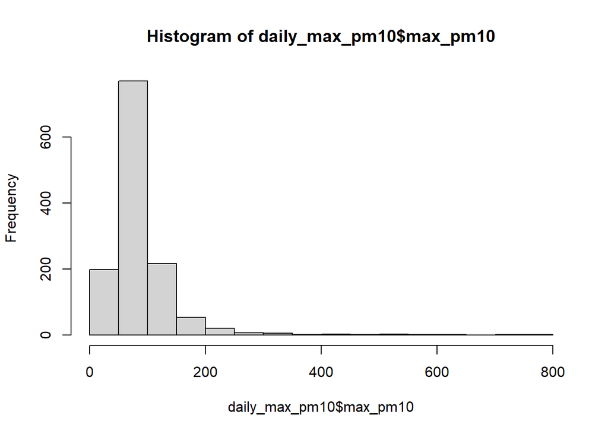

```r
hist(daily_max_pm10$max_pm10)
```

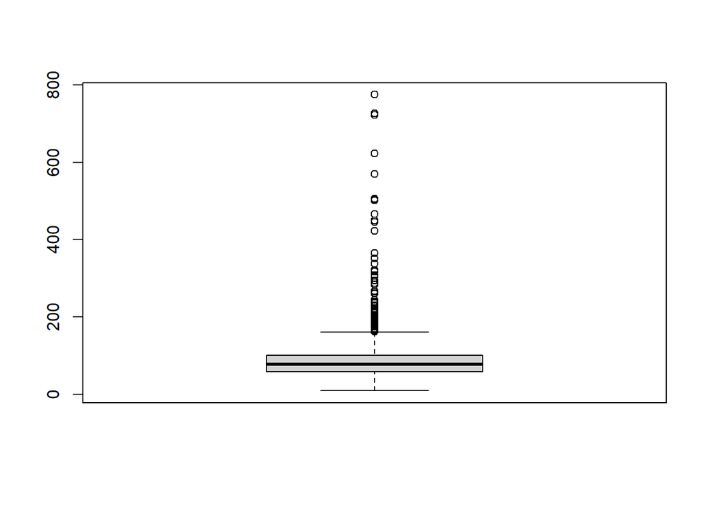

```r
boxplot(daily_max_pm10$max_pm10)
```

- daily_max_pm10$max_pm10의 요약 통계량을 추출했고, 평균, 분산, 표준편차까지 구해보았다. 또한, 히스토그램과 상자 그림 등을 이용하여 pm10 농도 변화량을 관찰하였다. 관찰한 결과 50-100 사이에 가장 많이 몰려 있었으며, 카이제곱 분포와 비슷한 경향을 띠는 것을 발견할 수 있었다.

# 문제3: Inferential Analysis I

```r
library(tidyverse)
pm10 <- data.frame()
for (year in 2009:2022) {
  file_path <- paste0("C:/Users/Samsung/Desktop/PM10/",year,".csv")
  data <- read.csv(file_path, fileEncoding='euc-kr')
  data <- data[,3:4]
  pm10 <- rbind(pm10, data)
}

df <- pm10 %>%
  separate(일시, c("Year", "Month", "Time"), "-") %>%
  separate(Time,c("Date","Time")," ") %>%
  filter(Month %in% c('03','04','05')) %>%
  unite(일시,Year,Month,Date,sep="-") %>%
  filter(!is.na(X1시간평균.미세먼지농도.....))

daily_max_pm10 <- df %>%
  mutate(일시=as.Date(일시),
         X1시간평균.미세먼지농도.....=as.numeric(X1시간평균.미세먼지농도.....)) %>%
  group_by(일시) %>%
  summarise(max_pm10=max(X1시간평균.미세먼지농도.....,na.rm=TRUE))

daily_max_pm10 %>% summary(daily_max_pm10)
```

```
##       일시               max_pm10
##  Min.   :2009-03-01   Min.   :  9.00
##  1st Qu.:2012-04-15   1st Qu.: 59.00
##  Median :2015-05-31   Median : 77.00
##  Mean   :2015-10-14   Mean   : 90.05
##  3rd Qu.:2019-04-15   3rd Qu.:100.00
##  Max.   :2022-05-31   Max.   :775.00
```

```r
daily_max_pm10 %>%
  summarise(mean_max=mean(max_pm10),
            var_max=var(max_pm10),
            sd_max=sd(max_pm10))
```

```
## # A tibble: 1 × 3
##   mean_max var_max sd_max
##      <dbl>   <dbl>  <dbl>
## 1     90.1   4153.   64.4
```

```r
standard_var=var(daily_max_pm10$max_pm10)
median=median(daily_max_pm10$max_pm10)

sigma_hat=sqrt(standard_var*6/(pi^2))
sigma_hat
```

```
## [1] 50.24585
```

```r
mu_hat=median+(sigma_hat*log(log(2)))
mu_hat
```

```
## [1] 58.58425
```

- mu의 추정치를 mu_hat에, sigma의 추정치를 sigma_hat에 저장하였다.

# 문제4: Inferential Analysis II

### 문제4-1.

```r
daily <- daily_max_pm10$max_pm10
head(daily)
```

```
## [1]  84  60  59 126 130 170
```

```r
f <- function(x,mu,sigma){
  return((1/sigma)*exp(-(x-mu)/sigma)*
           exp(-exp(-(x-mu)/sigma)))
}

g <- function(x,mu,sigma){
  return(-(1/n)*sum(log(f(x,mu,sigma))))
}

g_diff_mu <- function(x,mu,sigma){
  n <- length(x)
  return(-(1/n)*sum(((1/sigma) - (1/sigma) * exp(-(x-mu)/sigma))))
}

g_diff_sigma <- function(x,mu,sigma){
  n <- length(x)
  return(-(sum(((1 - exp(-((x-mu)/sigma))) * (x-mu)/sigma - 1)/sigma)/n))
}

gradg <- function(x,mu,sigma){
  return(c(g_diff_mu(x,mu,sigma),g_diff_sigma(x,mu,sigma)))
}
```

- 문제 3의 f(x)로부터 주어진 g(mu,sigma)를 R 함수로 구현했고, 도함수를 R 함수로 구현하여 gradg에 저장하였다.

### 문제4-2.

```r
daily <- daily_max_pm10$max_pm10
head(daily)
```

```
## [1]  84  60  59 126 130 170
```

```r
f <- function(x,mu,sigma){
  return((1/sigma)*exp(-(x-mu)/sigma)*
           exp(-exp(-(x-mu)/sigma)))
}

g <- function(x,mu,sigma){
  return(-(1/n)*sum(log(f(x,mu,sigma))))
}

g_diff_mu <- function(x,mu,sigma){
  n <- length(x)
  return(-(1/n)*sum(((1/sigma) - (1/sigma) * exp(-(x-mu)/sigma))))
}

g_diff_sigma <- function(x,mu,sigma){
  n <- length(x)
  return(-(sum(((1 - exp(-((x-mu)/sigma))) * (x-mu)/sigma - 1)/sigma)/n))
}

gradg <- function(x,mu,sigma){
  return(c(g_diff_mu(x,mu,sigma),g_diff_sigma(x,mu,sigma)))
}

mu <- sigma <- Inf
mu.new <- mu_hat; sigma.new <- sigma_hat
n <- length(daily)
while((abs(mu.new-mu)+abs(sigma.new-sigma))>=1e-05){
  eta <- 1
  mu <- mu.new;sigma <- sigma.new
  new <- c(mu,sigma)-eta*gradg(daily,mu,sigma)
  mu.new <- new[1];sigma.new <- new[2]

  while(g(daily,mu.new,sigma.new)>g(daily,mu,sigma)){
    eta <- eta*0.5
    new <- c(mu,sigma)-eta*gradg(daily,mu,sigma)
    mu.new <- new[1];sigma.new <- new[2]
  }
}
c(mu.new,sigma.new)
```

```
## [1] 68.96212 32.34695
```

- gradient descent 알고리즘을 이용하여 mu_hat_2, sigma_hat_2 값을 구했으며, 각각 mu.new, sigma.new에 저장하였다.

# 문제5: Model Diagnostics and Comparison

```r
daily <- daily_max_pm10$max_pm10
head(daily)
```

```
## [1]  84  60  59 126 130 170
```

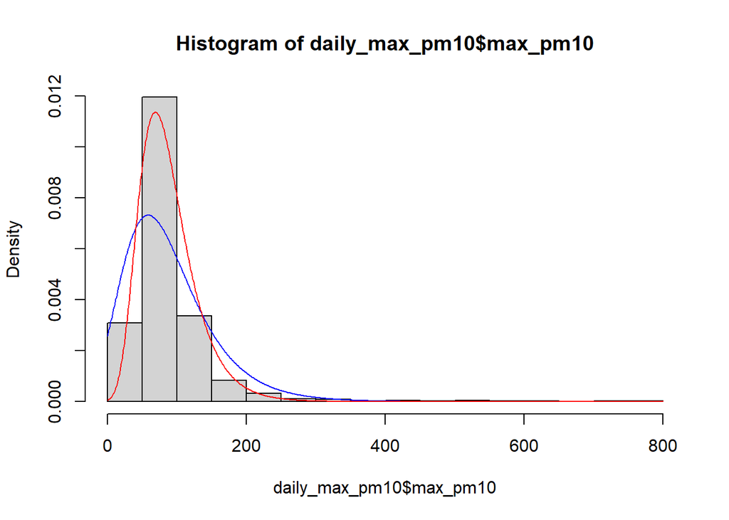

```r
f <- function(x,mu,sigma){
  return((1/sigma)*exp(-(x-mu)/sigma)*
           exp(-exp(-(x-mu)/sigma)))
}

hist(daily_max_pm10$max_pm10,prob=TRUE)

# 그래프 그리기
x <- seq(0,800,by=1.)
y1 <- f(x,mu_hat,sigma_hat)  # 확률밀도함수 계산
y2 <- f(x,mu.new,sigma.new)
lines(x, y1, type="l", col="blue", xlab="x", ylab="Density", main="Probability Density Function")
lines(x, y2, type="l", col="red", xlab="x", ylab="Density", main="Probability Density Function")
```

- (mu,sigma)가 (mu_hat,sigma_hat)일 때의 확률밀도함수 f(x)의 그래프와 (mu_hat_2,sigma_hat_2)일 때의 확률밀도함수 f(x)의 그래프를 히스토그램 위에 덧대어 그려 어느 방법으로 추정한 것이 자료의 분포를 더 잘 설명하는지 파악해보았다.
- 확인해본 결과 gradient descent 알고리즘을 이용하여 추정한 (mu_hat_2,sigma_hat_2)일 때의 확률밀도함수 f(x)가 자료의 분포를 더 잘 설명하고 있음을 알 수 있었다.